# ANALISI DATASET “NATIONAL LIFE EXPECTANCIES”

### HEALTHEXPEND

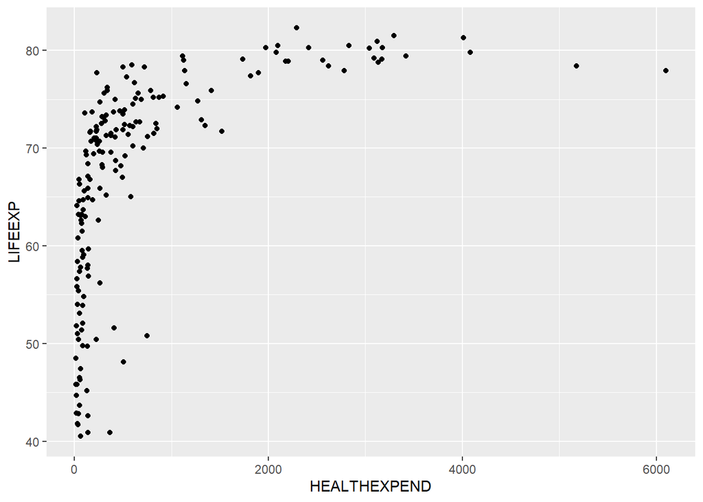

La distribuzione di questi dati è evidentemente non lineare, si può provare ad applicare la funzione logaritmo alla variabile sull’asse x per vedere se la correlazione lineare sale e se è possibile ricavare altre inforazioni.

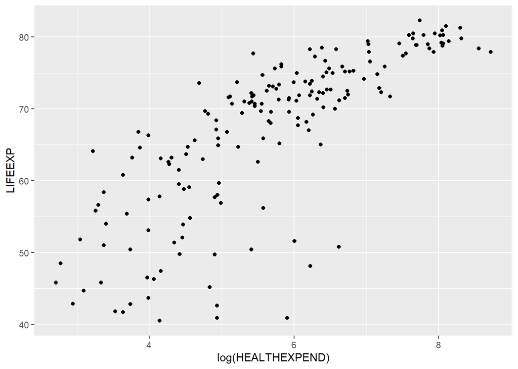

Dopo aver applicato il logaritmo alla variabile sull’asse x si può notare come la distribuzione dei dati sia più simile ad una retta che taglia il primo quadrante. Si mettono a confronto i due indici di correlazione con la variabile base e quella a cui è stata applicata una trasformazione.

```
## [1] 0.5637716
```

```
## [1] 0.7801348
```

Applicando il logaritmo alla variabile HEALTHEXPEND il valore dell’indice di correlazione sale da 0,5638 a 0,7801. Un’altra cosa che possiamo facilmente visualizzare per aggiungere informazioni al grafico è la regione di apparteneza dei diversi punti.

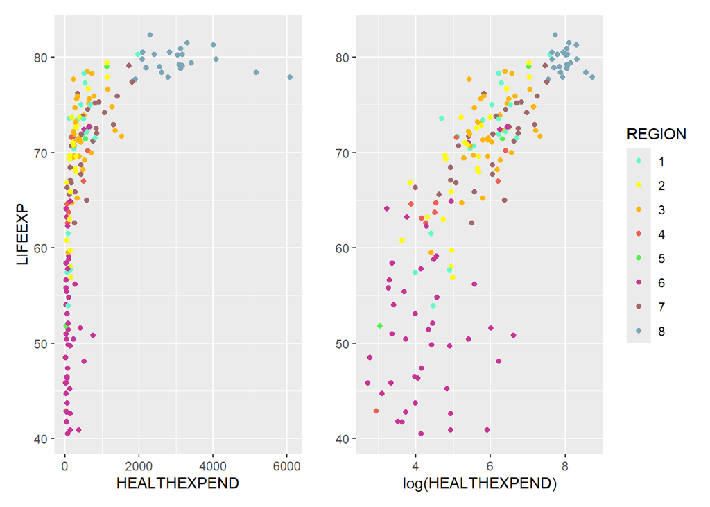

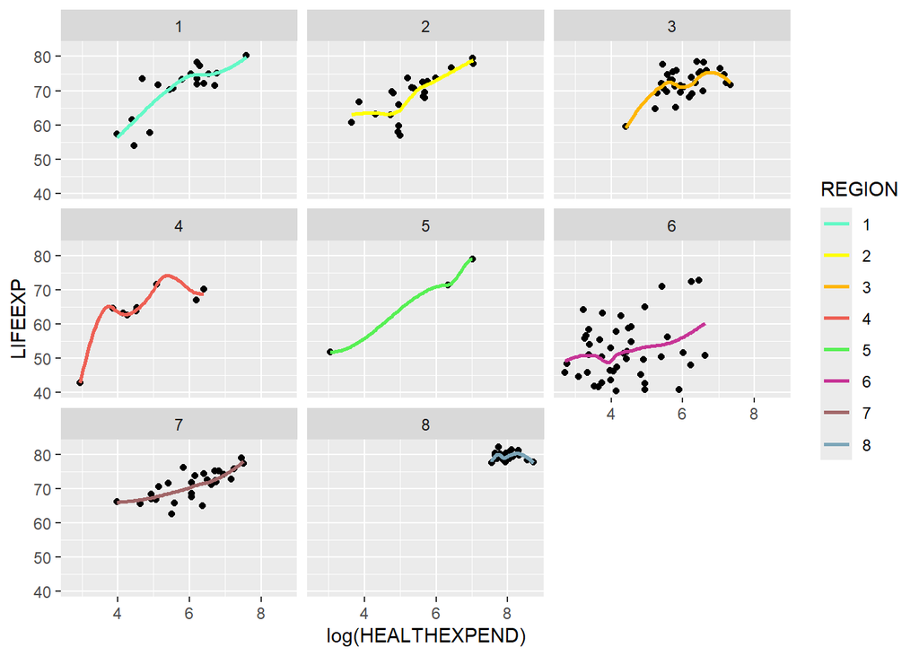

Si può facilmente notare la presenza di gruppi distinti sia prima che dopo aver applicato la trasformazione logaritmica. Essendo il coefficiente di correlazione lineare aumentato significativamente si ritiene opportuno costruire un modello lineare tra la variabile target e il logaritmo di HEALTHEXPEND.

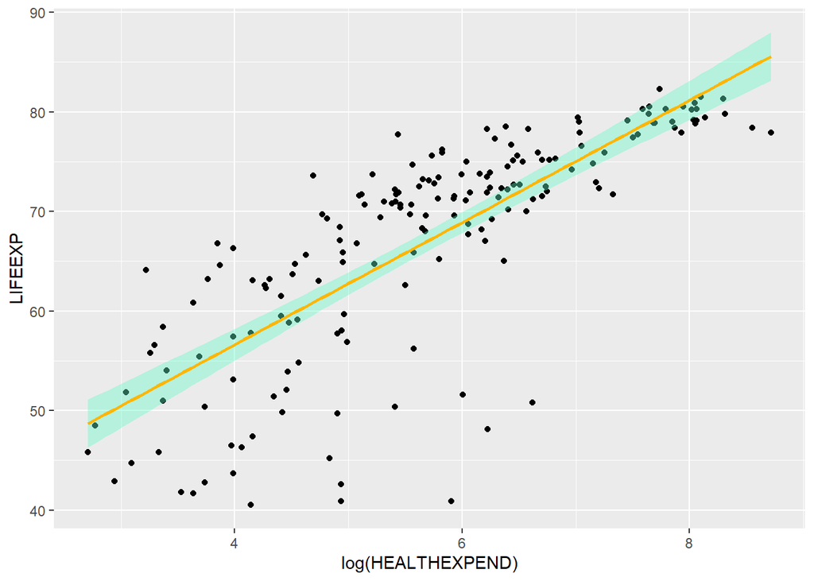

```r
summary(model)
```

```
##
## Call:
## lm(formula = LIFEEXP ~ log(HEALTHEXPEND), data = data)
##
## Residuals:
##     Min      1Q  Median      3Q     Max
## -27.412  -2.487   1.053   4.736  12.740
##
## Coefficients:
##                   Estimate Std. Error t value Pr(>|t|)
## (Intercept)        32.0659     2.1607   14.84   <2e-16 ***
## log(HEALTHEXPEND)   6.1377     0.3689   16.64   <2e-16 ***
## ---
## Signif. codes:  0 '***' 0.001 '**' 0.01 '*' 0.05 '.' 0.1 ' ' 1
##
## Residual standard error: 6.931 on 178 degrees of freedom
##   (5 osservazioni eliminate a causa di valori mancanti)
## Multiple R-squared:  0.6086, Adjusted R-squared:  0.6064
## F-statistic: 276.8 on 1 and 178 DF,  p-value: < 2.2e-16
```

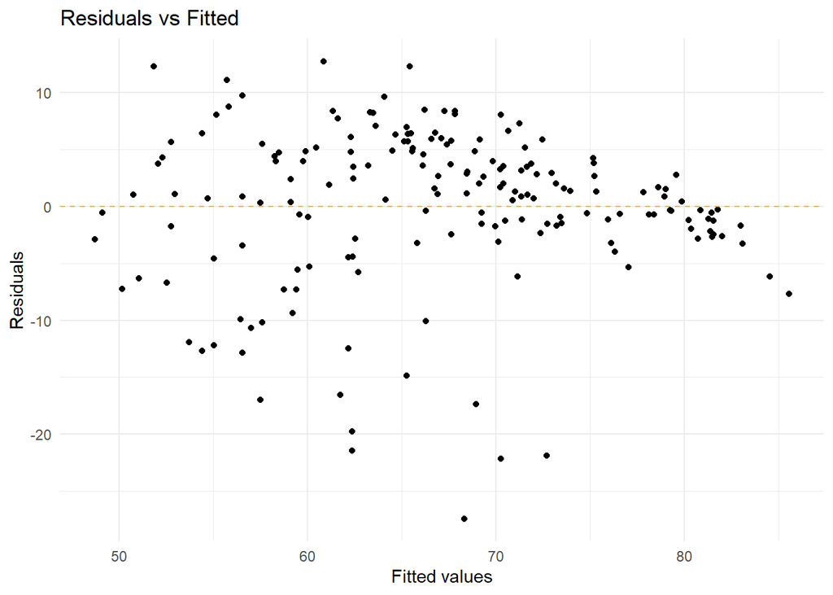

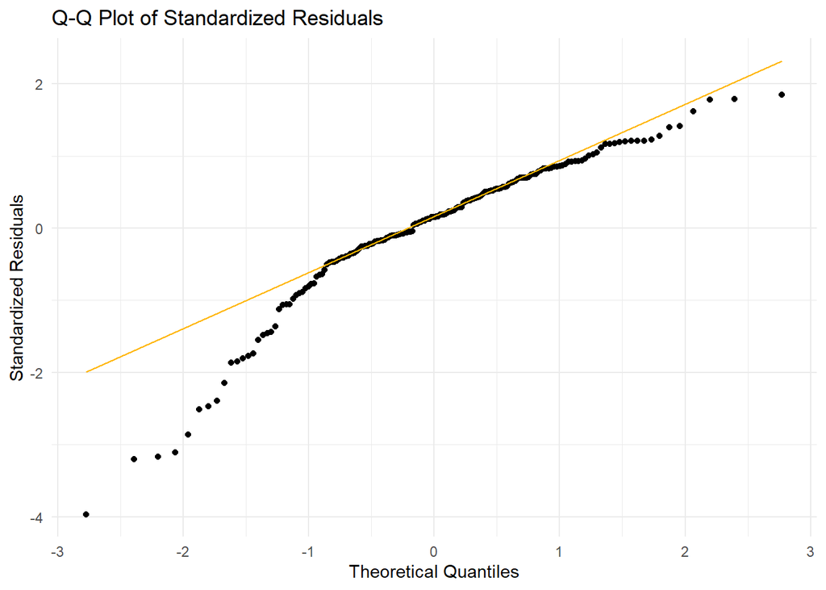

L’indice R^2 che indica la bontà del nostro modello lineare assume un valore di 0,6086, esprimendo come circa il 60% della variabilità dei dati può essere spiegata dal modello lineare, valore sufficientemente alto da dimostrare la bontà del modello. Anche in questo caso però i grafici dei residui non mostrano un comportamento desiderabile, conseguenza della distribuzione sparsa e asimmetrica delle osservazioni nello scatterplot iniziale.

### FERTILITY

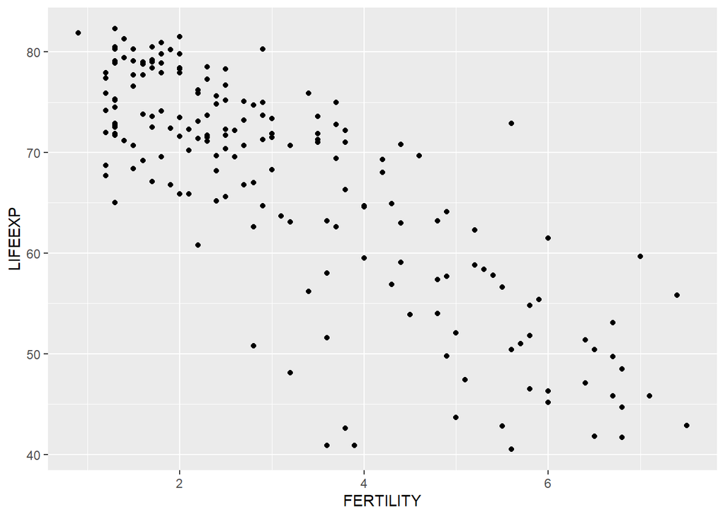

Un’altra cosa che possiamo facilmente visualizzare per aggiungere informazioni al grafico è la regione di apparteneza dei diversi punti.

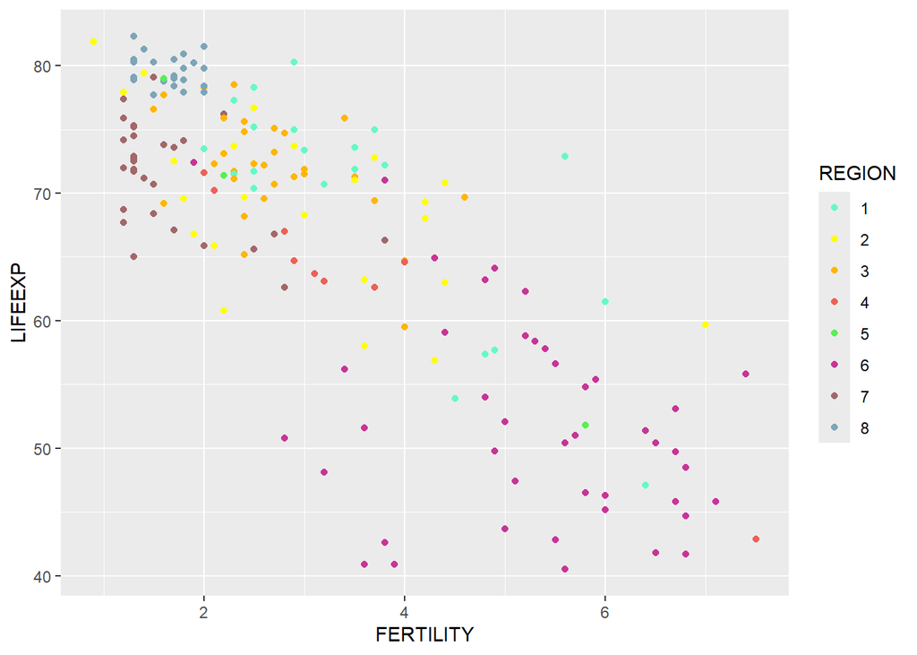

Nonostante anche in questo caso i punti siano piuttosto sparsi nello spazio, si riconosce, come per la variabile precedente, la vicinanza tra punti appartenenti alla stessa regione

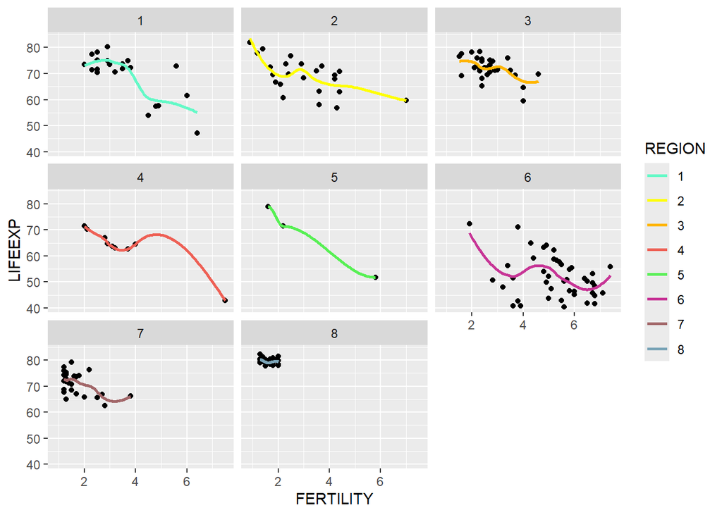

Notiamo come sia considerando separatamente i gruppi formati dalle regioni sia ossrvando il grafico generale, sembra essere presente una relazione lineare negativa tra le due variabili, come evidenziato dalla correlazione pari a -0,81. Ci aspettiamo quindi che una retta di regressione possa rappresentare bene il rapporto tra FERTILITY e LIFEEXP.

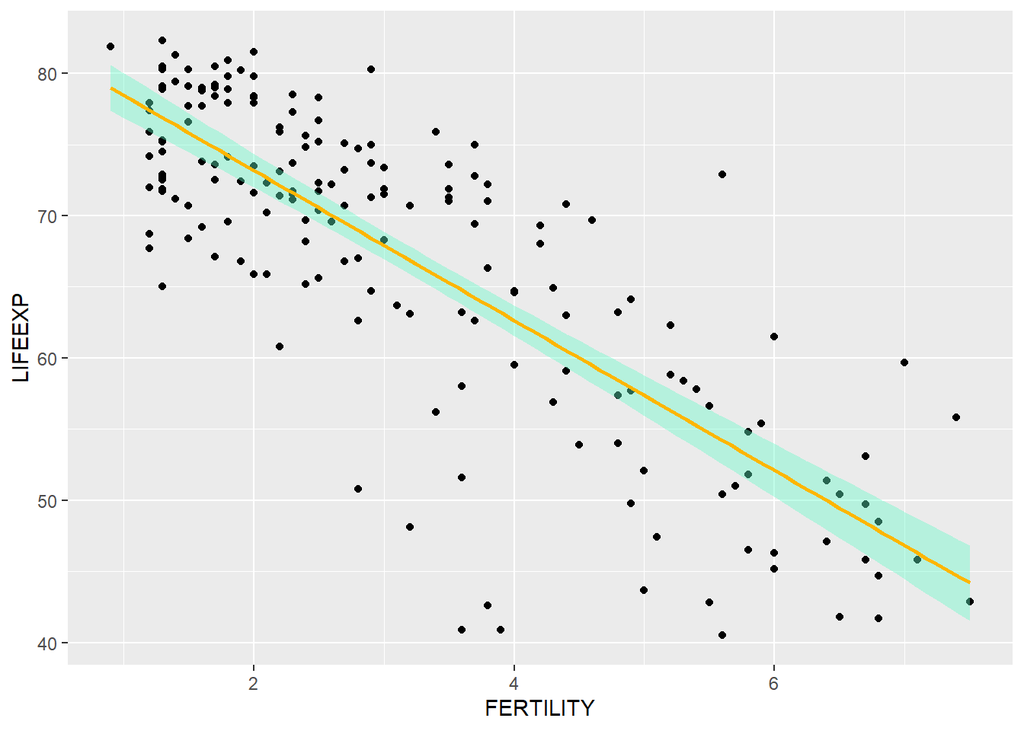

```r
summary(model)
```

```
##
## Call:
## lm(formula = LIFEEXP ~ FERTILITY, data = data)
##
## Residuals:
##      Min       1Q   Median       3Q      Max
## -23.8535  -3.7629   0.9397   4.5183  18.6935
##
## Coefficients:
##             Estimate Std. Error t value Pr(>|t|)
## (Intercept)  83.7381     1.0439   80.22   <2e-16 ***
## FERTILITY    -5.2735     0.2887  -18.27   <2e-16 ***
## ---
## Signif. codes:  0 '***' 0.001 '**' 0.01 '*' 0.05 '.' 0.1 ' ' 1
##
## Residual standard error: 6.615 on 179 degrees of freedom
##   (4 osservazioni eliminate a causa di valori mancanti)
## Multiple R-squared:  0.6508, Adjusted R-squared:  0.6489
## F-statistic: 333.7 on 1 and 179 DF,  p-value: < 2.2e-16
```

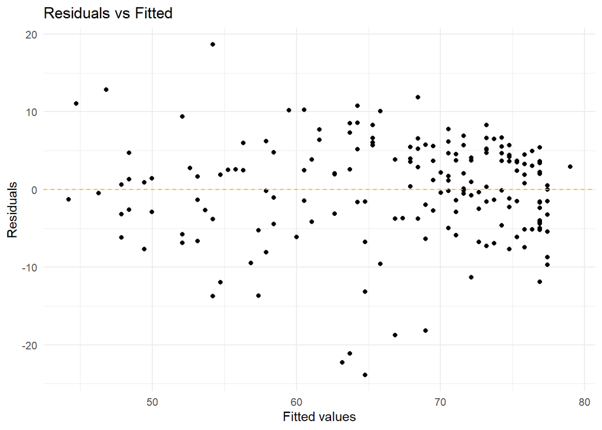

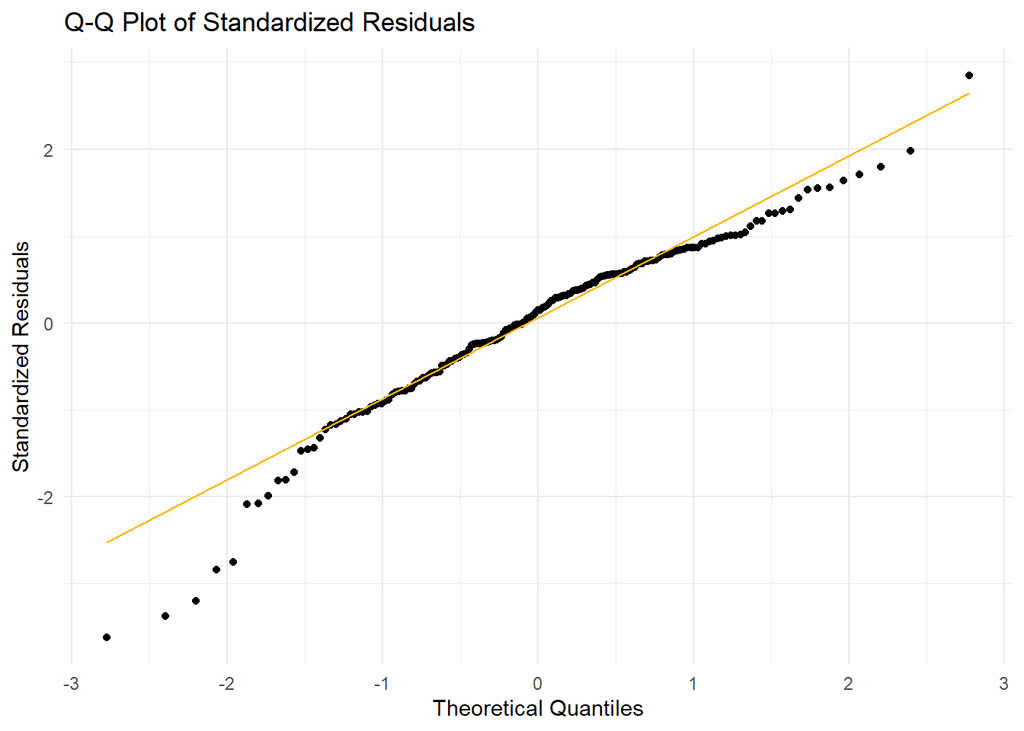

Analizzando questo modello di regressione lineare, troviamo un indice R^2 pari a 0.6508, valore che ci esprime come la retta svolga una buona approssimazione dei dati. Il comportamento dei residui è più casuale rispetto alle analisi precedenti, mentre rimane simile ai casi precedenti la varianza degli scarti rispetto al valore medio.

```r
summary(model)
```

```
##
## Call:
## lm(formula = LIFEEXP ~ FERTILITY, data = data)
##
## Residuals:
##      Min       1Q   Median       3Q      Max
## -23.8535  -3.7629   0.9397   4.5183  18.6935
##
## Coefficients:
##             Estimate Std. Error t value Pr(>|t|)
## (Intercept)  83.7381     1.0439   80.22   <2e-16 ***
## FERTILITY    -5.2735     0.2887  -18.27   <2e-16 ***
## ---
## Signif. codes:  0 '***' 0.001 '**' 0.01 '*' 0.05 '.' 0.1 ' ' 1
##
## Residual standard error: 6.615 on 179 degrees of freedom
##   (4 osservazioni eliminate a causa di valori mancanti)
## Multiple R-squared:  0.6508, Adjusted R-squared:  0.6489
## F-statistic: 333.7 on 1 and 179 DF,  p-value: < 2.2e-16
```

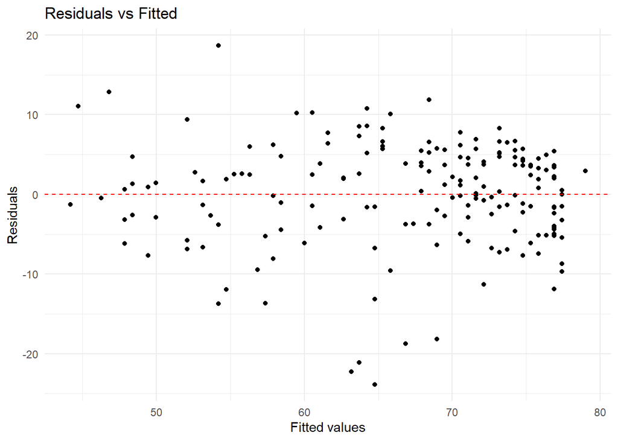

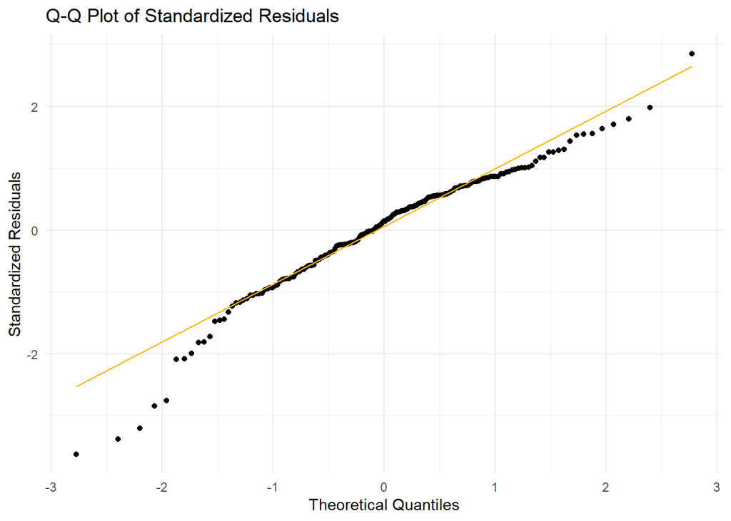

Analizzando questo modello di regressione lineare, troviamo un indice R^2 pari a 0.6508, valore che rappresenta una buona approssimazione dei dati da parte della retta. Il comportamento dei residui è più casuale rispetto alle analisi precedenti, ma rimane simile ai casi precedenti la varianza rispetto al valore medio.

### BIRTHATTEND

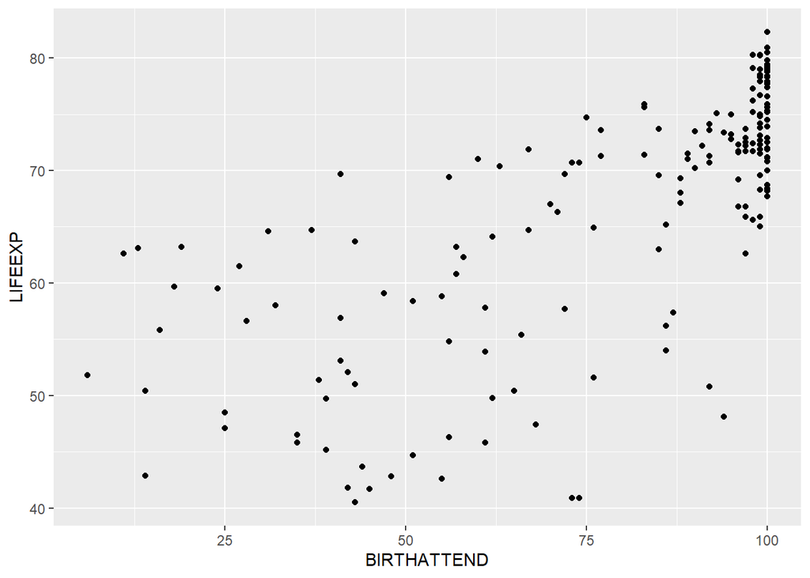

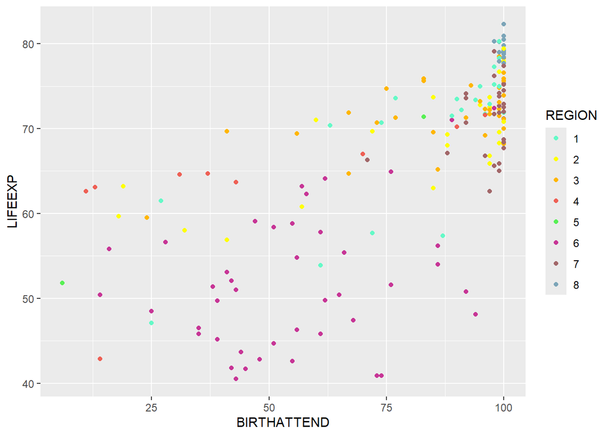

Notiamo nuovamente due comportanmenti distinti dei punti osservati, i quali si disperdono nello spazio con una tendenza a crescere per poi concentrarsi in alto a destra nel grafico. Anche evidenziando le regioni, non sembra che i gruppi siano tanto disinguibili quanto nei casi precedenti. Ricordando come il coefficiente di correlazione lineare delle due variabili sia pari a 0,72 il modello di regressione lineare dovrebbe poter rappresentare bene il rapporto sotteso ai dati. Non dovrebbe stupire infatti che nei paesi in cui la presenza di personale specializzato ad assistere le nascite è capillare, la qualità della vita e di conseguenza la sua durata media sarà maggiore.

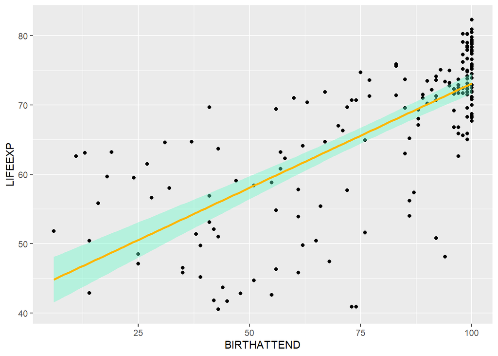

```r
summary(model)
```

```
##
## Call:
## lm(formula = LIFEEXP ~ BIRTHATTEND, data = data)
##
## Residuals:
##     Min      1Q  Median      3Q     Max
## -24.378  -3.560   1.302   5.189  16.286
##
## Coefficients:
##             Estimate Std. Error t value Pr(>|t|)
## (Intercept) 43.00259    1.78803   24.05   <2e-16 ***
## BIRTHATTEND  0.30102    0.02166   13.90   <2e-16 ***
## ---
## Signif. codes:  0 '***' 0.001 '**' 0.01 '*' 0.05 '.' 0.1 ' ' 1
##
## Residual standard error: 7.612 on 176 degrees of freedom
##   (7 osservazioni eliminate a causa di valori mancanti)
## Multiple R-squared:  0.5233, Adjusted R-squared:  0.5206
## F-statistic: 193.2 on 1 and 176 DF,  p-value: < 2.2e-16
```

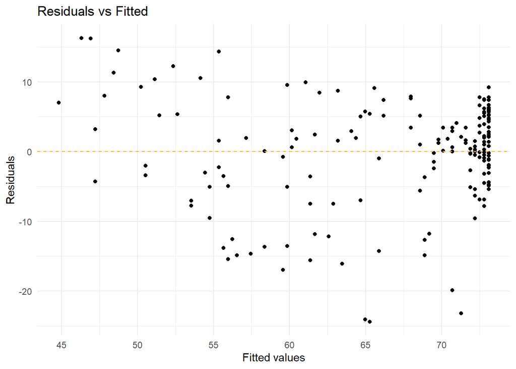

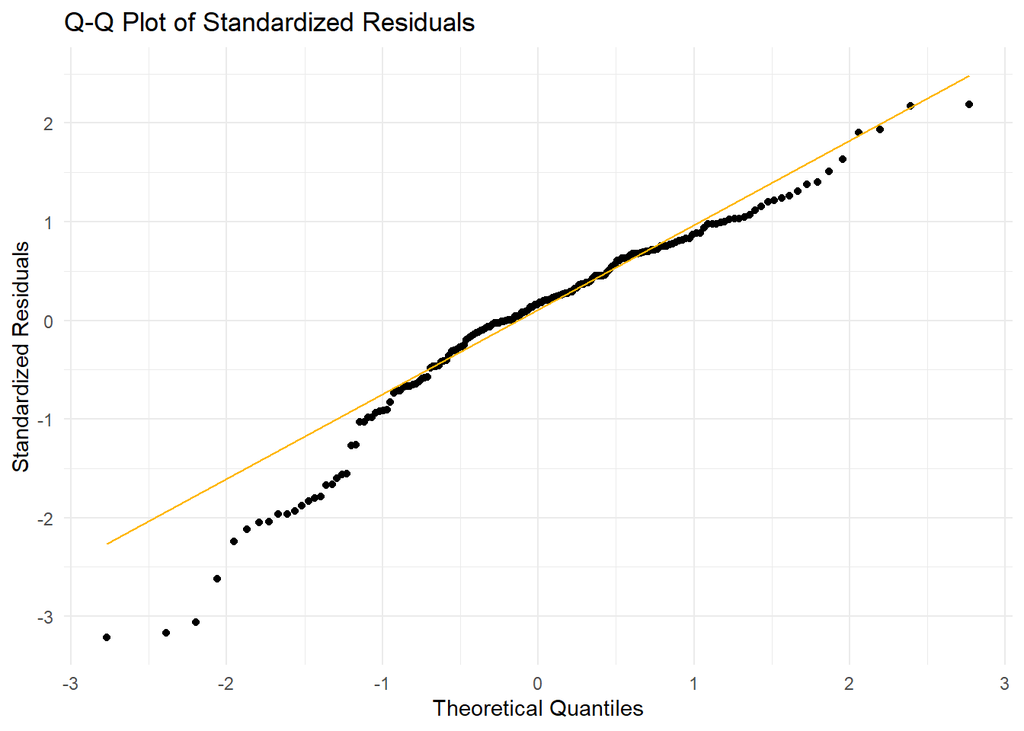

Il modello di regressione ha un R^2 pari a 0,5233, valore inferiore alle aspettative probabilmente a causa della solita varianza residua elevata dovuta alla dispersione dei punti nello spazio. Il grafico dei residui sembra mostrare una tendenza negativa degli scarti dalla retta, comportamento che ci porta a dubitare ulteriormente della bontà del modello realizzato.

### GDP

GDP non è una variabile con un indice di correlazione molto alto, tuttavia il GDP secondo noi dovrebbe essere un fattore correlato all’aspettativa di vita e decidiamo dunque di eseguire ugualmente un’analisi, nella speranza di ottenere risultati da sfruttare anche in un secondo momento.

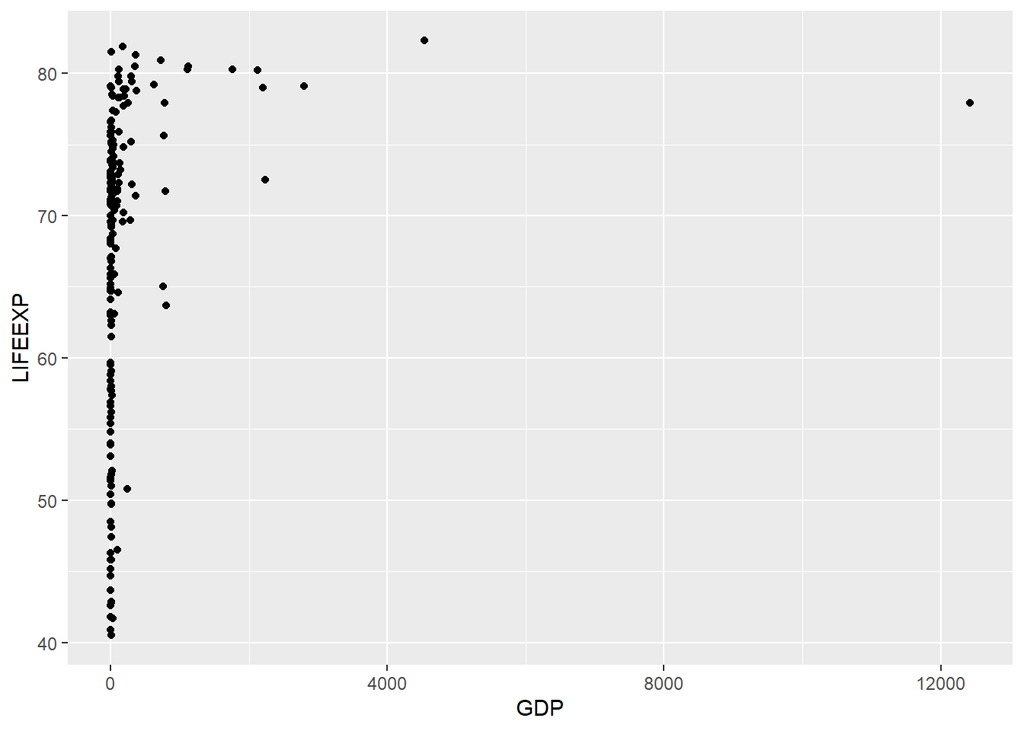

Come potevamo aspettarci dall’indice di Pearson è difficile anche solo visualizzare una retta (diversa da una retta verticale) che approssimi i dati in maniera efficace. Tuttavia potrebbe essere per noi interessante andare a vedere se, considerando solo i paesi con un GDP maggiore ad una certa soglia, otteniamo risultati migliori. Vengono rimossi anche i valori di Stati Uniti e Giappone in quanto costituiscono outliers.

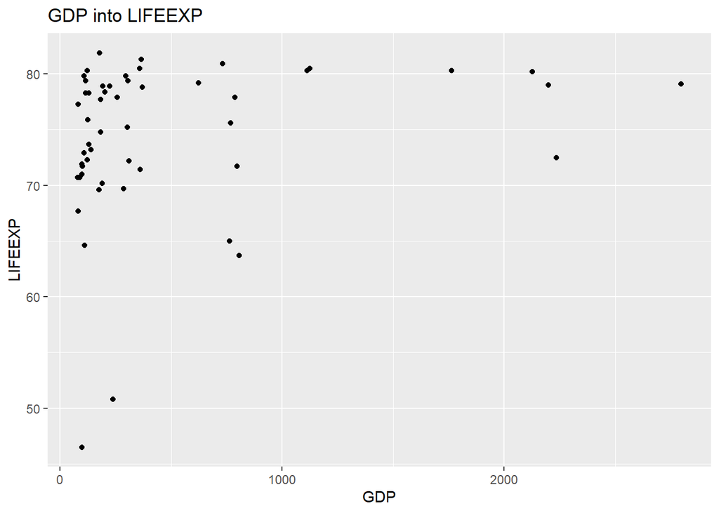

I risultati non sembrano migliorare. Considerando quindi il basso valore dell’indice di correlazione e la rappresentazione grafica ottenuta,riconosciamo la mancanza di una relazione tra GDP e LIFEEXP (anche solo localmente). Come ultimo test proviamo a visulizzare il grafico a dispersione evidenziando le regioni.

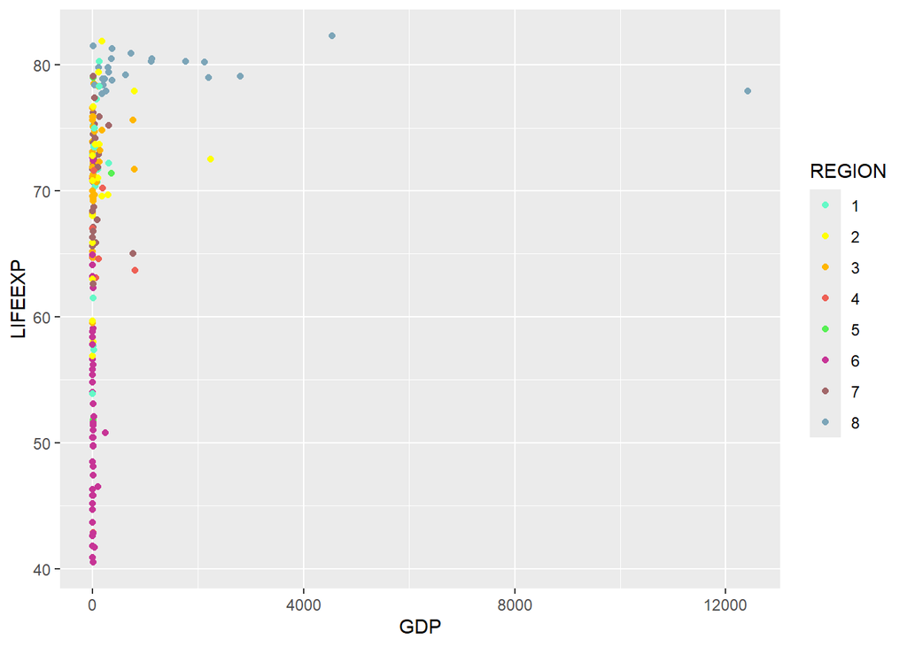

Concludiamo che nemmeno i comportamenti regionali sembrano assumere forma lineare, tuttavia potremmo dedurre che REGION definisce abbastanza bene alcuni gruppi in questa analisi, soprattutto per quanto riguarda la regione 6, la 3 e la 8.

### PHYSICIAN

Come già commentato durante l’analisi univariata, abbiamo alte aspettative per la variabile physician di essere influente per LIFEEXP. Cominciamo subito visualizzando lo scatterplot.

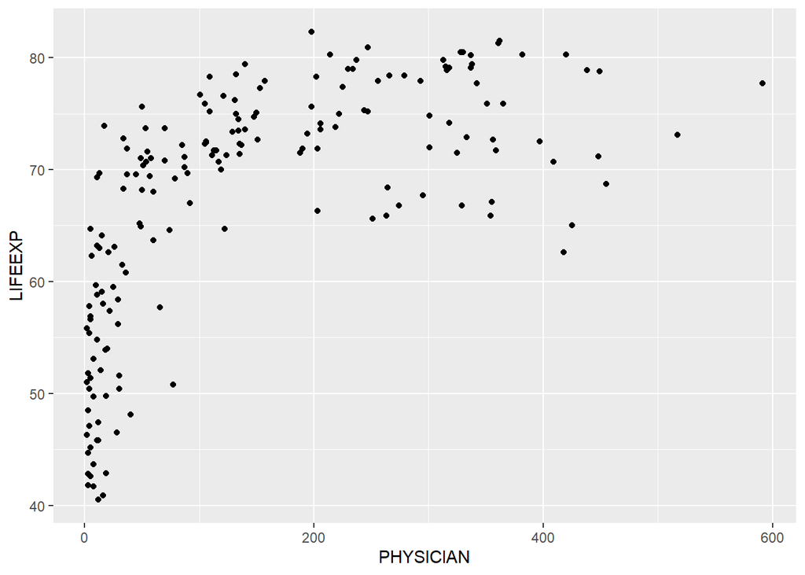

Il grafico non fa che confermare i risultati ottenuti con il calcolo dell’indice di Pearson, e dobbiamo ammettere di essere molto soddisfatti da ciò. Proviamo allora a disegnare la retta dei minimi quadrati, visualizzandone anche l’intervallo di confidenza al 95%.

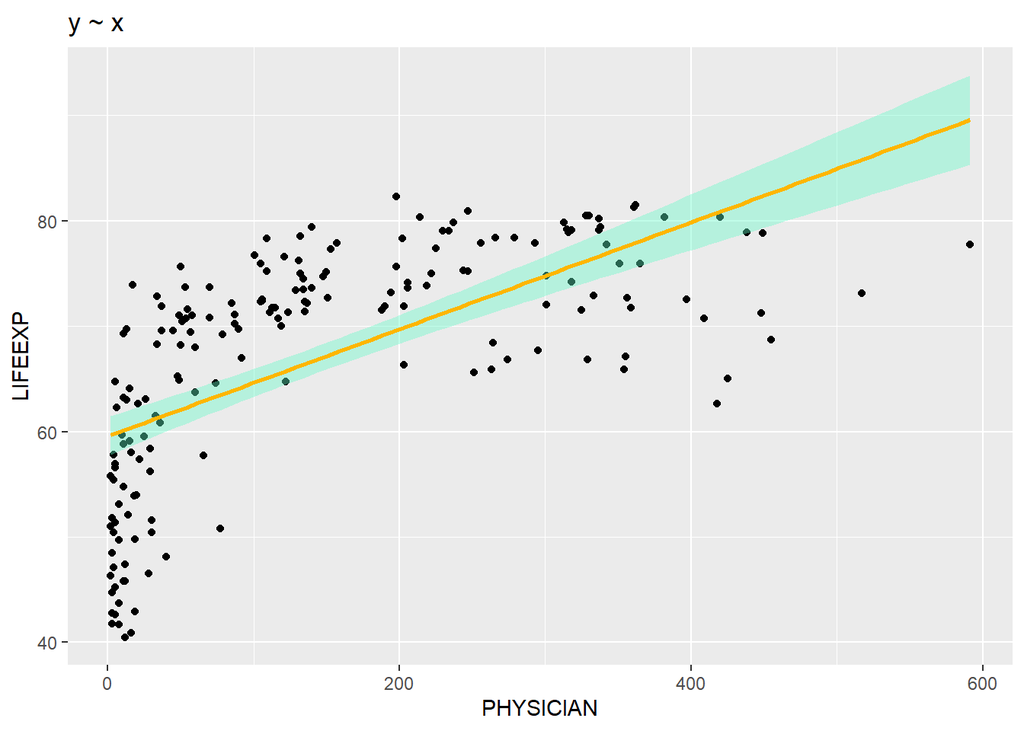

```r
model = lm(LIFEEXP~PHYSICIAN, data)
summary(model)
```

```
##
## Call:
## lm(formula = LIFEEXP ~ PHYSICIAN, data = data)
##
## Residuals:
##     Min      1Q  Median      3Q     Max
## -19.655  -6.560   2.749   6.959  13.517
##
## Coefficients:
##              Estimate Std. Error t value Pr(>|t|)
## (Intercept) 59.545693   0.929939   64.03   <2e-16 ***
## PHYSICIAN    0.050744   0.004625   10.97   <2e-16 ***
## ---
## Signif. codes:  0 '***' 0.001 '**' 0.01 '*' 0.05 '.' 0.1 ' ' 1
##
## Residual standard error: 8.621 on 180 degrees of freedom
##   (3 osservazioni eliminate a causa di valori mancanti)
## Multiple R-squared:  0.4008, Adjusted R-squared:  0.3974
## F-statistic: 120.4 on 1 and 180 DF,  p-value: < 2.2e-16
```

I risultati del summary mostrano un valore di R^2 di 0,3974, abbastanza basso da farci dubitare della relazione lineare semplice. Come potevamo aspettarci vengono individuati alcuni outlier, sia a sinistra che a destra, tuttavia non ci stupisce molto poiché già presupponevamo l’esistenza di questo fenomeno dall’analisi univariata.

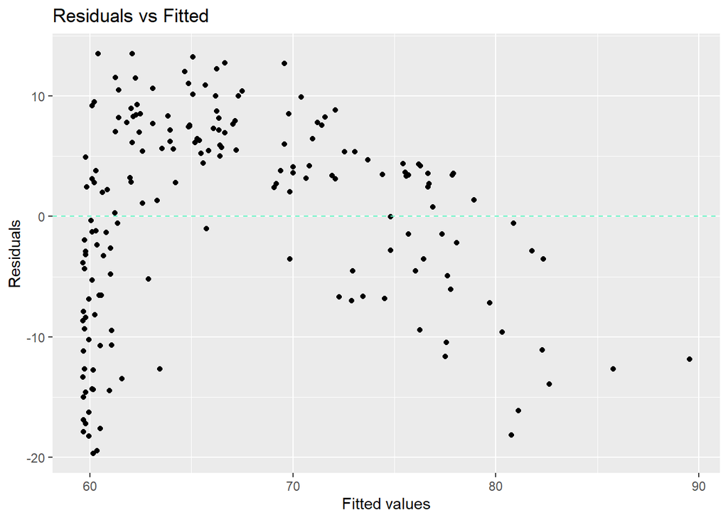

Abbiamo una forte eteroschedasticità e occorre quasi sicuramente pensare di trasformare i dati per ottenere risultati migliori. Vediamo prima di procedere cosa ci indica il grafico QQ SResiduals.

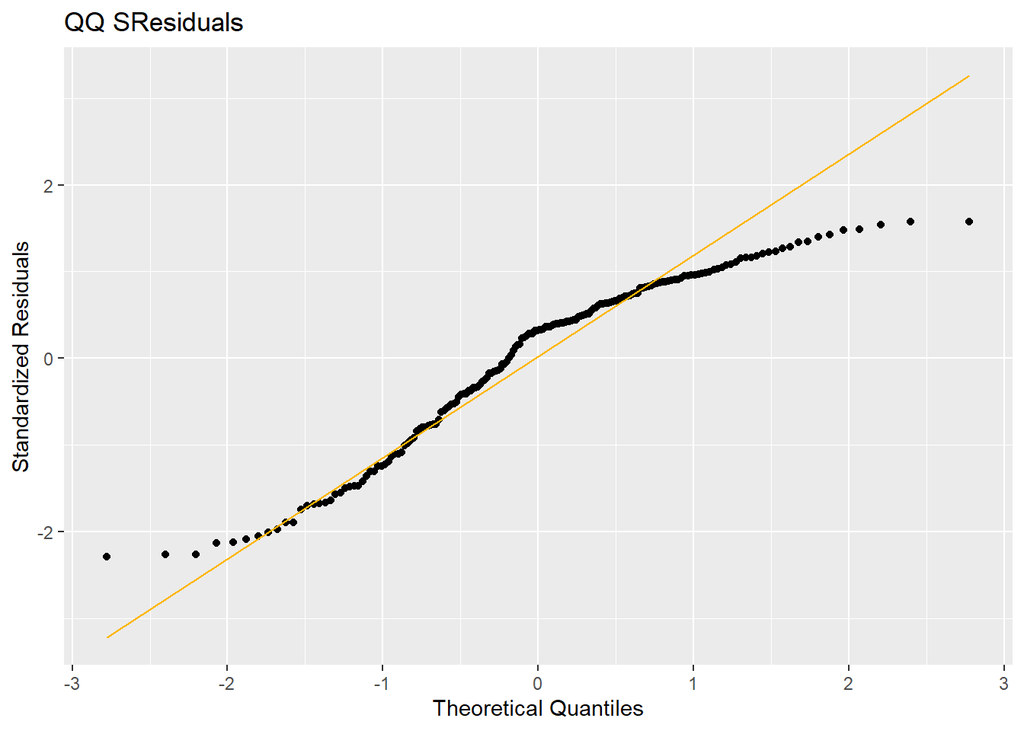

Sembra non esserci una distribuzione degli errori che segue distribuzione normale standard, e come precedemente già valutato ci viene il dubbio che sia necessario effettuare una trasformazione dei dati per ottenere dei risultati soddisfacenti. Dunque proviamo a considerare il log(PHYSICIAN).

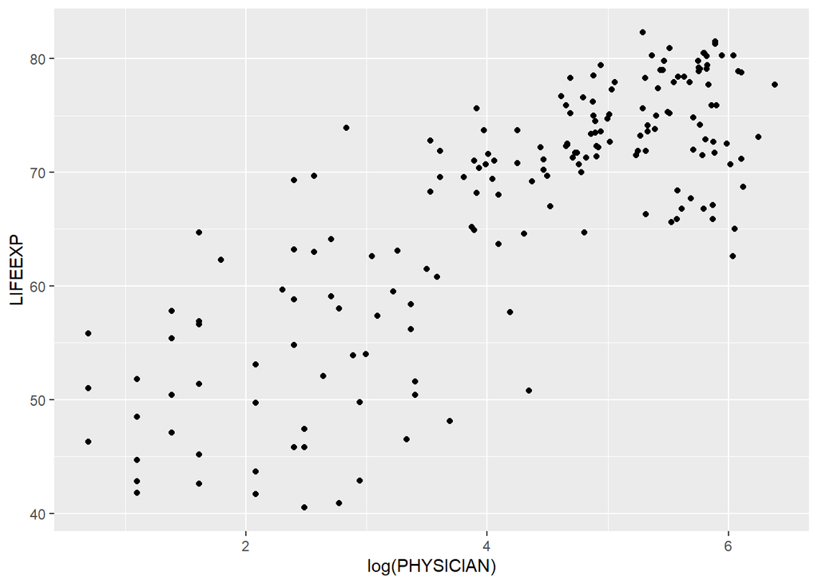

Notiamo un netto miglioramento nella rappresentazione dei dati, dunque non ci resta che vedere il comportamento della retta di regressione lineare.

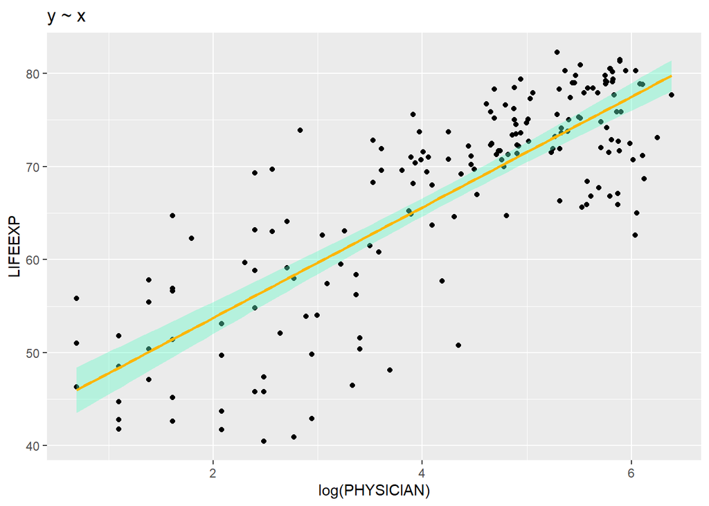

Notiamo che la retta approssima sicuramente molto meglio rispetto a prima, ed infatti anche l’intervallo di confidenza si è ristretto rispetto. Calcoliamo il miglioramento in termini di correlazione tra prima e dopo ed eseguiamo un summary sul modello lineare per visualizzare altri tipi di miglioramento.

```r
res = cor(log(data$PHYSICIAN), data$LIFEEXP, method = "pearson", use = "pairwise.complete.obs")
res
```

```
## [1] 0.8065166
```

```r
model = lm(LIFEEXP~log(PHYSICIAN) , data)
summary(model)
```

```
##
## Call:
## lm(formula = LIFEEXP ~ log(PHYSICIAN), data = data)
##
## Residuals:
##     Min      1Q  Median      3Q     Max
## -17.426  -3.740   1.169   4.402  15.214
##
## Coefficients:
##                Estimate Std. Error t value Pr(>|t|)
## (Intercept)     41.8539     1.4559   28.75   <2e-16 ***
## log(PHYSICIAN)   5.9411     0.3246   18.30   <2e-16 ***
## ---
## Signif. codes:  0 '***' 0.001 '**' 0.01 '*' 0.05 '.' 0.1 ' ' 1
##
## Residual standard error: 6.584 on 180 degrees of freedom
##   (3 osservazioni eliminate a causa di valori mancanti)
## Multiple R-squared:  0.6505, Adjusted R-squared:  0.6485
## F-statistic:   335 on 1 and 180 DF,  p-value: < 2.2e-16
```

```r
model = lm(LIFEEXP~PHYSICIAN + I(PHYSICIAN^2) , data)
summary(model)
```

```
##
## Call:
## lm(formula = LIFEEXP ~ PHYSICIAN + I(PHYSICIAN^2), data = data)
##
## Residuals:
##     Min      1Q  Median      3Q     Max
## -16.202  -4.039   1.073   4.330  21.138
##
## Coefficients:
##                  Estimate Std. Error t value Pr(>|t|)
## (Intercept)     5.468e+01  9.348e-01  58.500   <2e-16 ***
## PHYSICIAN       1.552e-01  1.203e-02  12.901   <2e-16 ***
## I(PHYSICIAN^2) -2.573e-04  2.809e-05  -9.159   <2e-16 ***
## ---
## Signif. codes:  0 '***' 0.001 '**' 0.01 '*' 0.05 '.' 0.1 ' ' 1
##
## Residual standard error: 7.134 on 179 degrees of freedom
##   (3 osservazioni eliminate a causa di valori mancanti)
## Multiple R-squared:  0.592,  Adjusted R-squared:  0.5874
## F-statistic: 129.9 on 2 and 179 DF,  p-value: < 2.2e-16
```

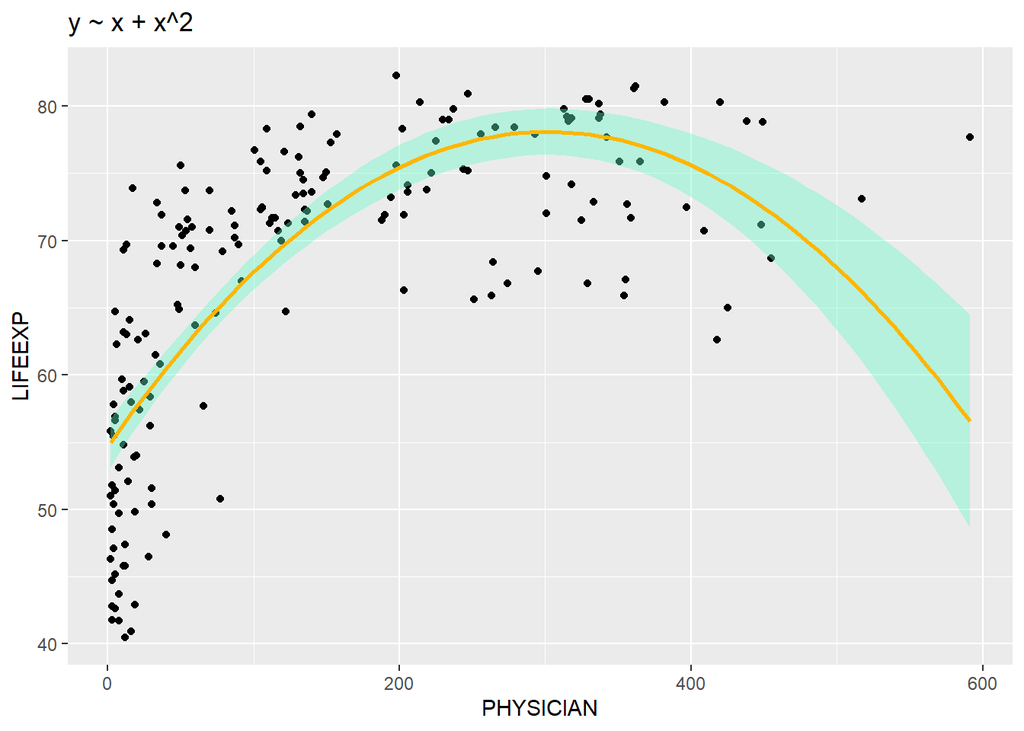

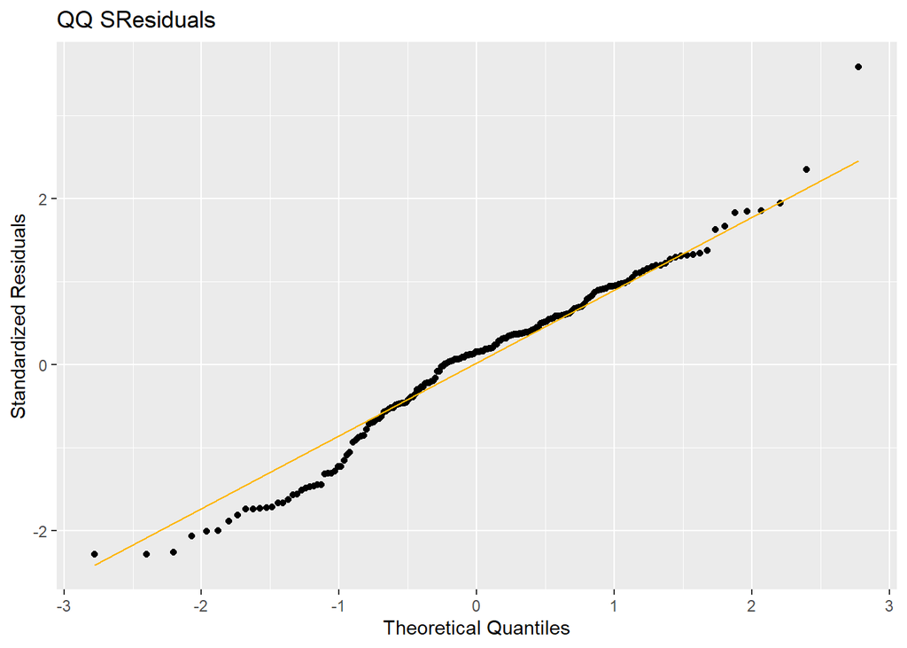

Notiamo, grazie al QQSResiduals un miglioramento significativo per quanto riguarda le code della distribuzione. Concludiamo dunque la nostra analisi bivariata della variabile PHYSICIAN.

## Analisi Multivariata

##### Analisi multivariata con target LIFEEXP

In questo paragrafo possiamo finalmente dedicarci all’analisi multivariata del nostro dataset con variabile target LIFEEXP. Ci approcceremo in 3 maniere diverse:

1. Aggiunta delle variabili più rilevanti trovate sino ad ora tramite le analisi precedentemente eseguite in un modello unico
2. Uso del metodo stepAIC della libreria MASS a partire dal modello nullo al modello che comprende tutte le variabili in maniera lineare
3. Combinazione dei risultati ottenuti dagli approcci 1 e 2 provando a trasformare qualora servissero le variabili considerate

### APPROCCIO 1

Come primo approccio proviamo a perndere le variabili che hanno dato i risultati migliori nell’analisi bivariata per poi utilizzarle in un modello di regressione lineare multivariatia. Si decide di selezionare le variabili che hanno mostrato un indice R^2 superiore a 0,6 ovvero FERTILITTY, PHYSICIAN (il suo logaritmo), HEALTHEXPEND (anche in questo caso il logaritmo).

```r
model <- lm(LIFEEXP ~ FERTILITY + log(PHYSICIAN) + log(HEALTHEXPEND), data = data)
summary(model)
```

```
##
## Call:
## lm(formula = LIFEEXP ~ FERTILITY + log(PHYSICIAN) + log(HEALTHEXPEND),
##     data = data)
##
## Residuals:
##      Min       1Q   Median       3Q      Max
## -21.5130  -2.5545   0.8333   3.4719  11.4530
##
## Coefficients:
##                   Estimate Std. Error t value Pr(>|t|)
## (Intercept)        49.5135     4.7464  10.432  < 2e-16 ***
## FERTILITY          -1.9510     0.5338  -3.655 0.000342 ***
## log(PHYSICIAN)      2.4435     0.5792   4.219 3.98e-05 ***
## log(HEALTHEXPEND)   2.3256     0.5201   4.472 1.41e-05 ***
## ---
## Signif. codes:  0 '***' 0.001 '**' 0.01 '*' 0.05 '.' 0.1 ' ' 1
##
## Residual standard error: 5.753 on 171 degrees of freedom
##   (10 osservazioni eliminate a causa di valori mancanti)
## Multiple R-squared:  0.7388, Adjusted R-squared:  0.7343
## F-statistic: 161.3 on 3 and 171 DF,  p-value: < 2.2e-16
```

Notiamo subito un miglioramento dell’indice R^2 rispetto alle analisi bivariate, risultato che ci aspettavamo considerando come sono state scelte le varaibili predittive. Proviamo ora ad aggiungere la variabile categoriale REGION nel modello, dato che la riteniamo importante nella determinazione delle aspettative di vita.

```r
model <- lm(LIFEEXP ~ FERTILITY + log(PHYSICIAN) + log(HEALTHEXPEND) + REGION, data = data)
summary(model)
```

```
##
## Call:
## lm(formula = LIFEEXP ~ FERTILITY + log(PHYSICIAN) + log(HEALTHEXPEND) +
##     REGION, data = data)
##
## Residuals:
##      Min       1Q   Median       3Q      Max
## -16.3015  -1.7300   0.1007   2.8625  12.7747
##
## Coefficients:
##                   Estimate Std. Error t value Pr(>|t|)
## (Intercept)        59.6481     5.3894  11.068  < 2e-16 ***
## FERTILITY          -1.6572     0.5242  -3.162  0.00187 **
## log(PHYSICIAN)      1.6384     0.5903   2.776  0.00615 **
## log(HEALTHEXPEND)   1.5311     0.5902   2.594  0.01033 *
## REGION2            -0.1737     1.6753  -0.104  0.91754
## REGION3            -0.1689     1.4732  -0.115  0.90886
## REGION4            -3.5194     2.1326  -1.650  0.10080
## REGION5            -1.5706     3.1145  -0.504  0.61474
## REGION6            -9.5674     1.7172  -5.572 1.02e-07 ***
## REGION7            -4.4165     1.6461  -2.683  0.00804 **
## REGION8             1.0742     1.8195   0.590  0.55574
## ---
## Signif. codes:  0 '***' 0.001 '**' 0.01 '*' 0.05 '.' 0.1 ' ' 1
##
## Residual standard error: 4.941 on 164 degrees of freedom
##   (10 osservazioni eliminate a causa di valori mancanti)
## Multiple R-squared:  0.8152, Adjusted R-squared:  0.8039
## F-statistic: 72.34 on 10 and 164 DF,  p-value: < 2.2e-16
```

```r
AIC(model)
```

```
## [1] 1068.447
```

Osserivamo un aumento significativo dell’indice R^2, a conferma della nostra ipotesi. abbiamo quindi ottenuto un buon modello predittivo utilizzando quattro variabili

### APPROCCIO 2

Il metodo stepAIC() è una funzione di selezione del modello che utilizza il criterio di informazione di Akaike (AIC) per determinare quali variabili includere nel modello. Partendo dal modello più semplice possibile (il modello nullo) ed aggiungendo variabili (talvolta rimuovendole se serve) il metodo seleziona ad ogni passo il modello con il minor AIC fino ad arrivare ad un punto in cui non può più migliorare (il miglior modello raggiungibile).

```r
clean_data = na.omit(data)
nrow(clean_data)
```

```
## [1] 131
```

```r
null_model = lm(LIFEEXP ~ 1, clean_data)

full_model = lm(LIFEEXP ~ ., clean_data)

best_model = stepAIC(null_model, trace = 0, scope = list(lower = null_model, upper = full_model), direction = "both")

summary(best_model)
```

```
##
## Call:
## lm(formula = LIFEEXP ~ REGION + BIRTHATTEND + PUBLICEDUCATION +
##     ILLITERATE + FERTILITY + HEALTHEXPEND, data = clean_data)
##
## Residuals:
##      Min       1Q   Median       3Q      Max
## -12.5141  -2.2139   0.0434   2.4993  15.8932
##
## Coefficients:
##                   Estimate Std. Error t value Pr(>|t|)
## (Intercept)      6.579e+01  5.319e+00  12.369  < 2e-16 ***
## REGION2         -3.177e+00  1.951e+00  -1.629 0.106062
## REGION3         -1.523e+00  1.769e+00  -0.861 0.391045
## REGION4         -4.095e+00  2.728e+00  -1.501 0.136004
## REGION5         -3.362e+00  3.106e+00  -1.082 0.281330
## REGION6         -1.642e+01  1.810e+00  -9.072 3.13e-15 ***
## REGION7         -4.672e+00  1.910e+00  -2.446 0.015914 *
## REGION8         -3.468e-02  2.773e+00  -0.013 0.990045
## BIRTHATTEND      1.431e-01  3.808e-02   3.757 0.000269 ***
## PUBLICEDUCATION -5.372e-01  2.186e-01  -2.457 0.015459 *
## ILLITERATE       1.076e-01  4.143e-02   2.596 0.010624 *
## FERTILITY       -1.531e+00  6.585e-01  -2.325 0.021758 *
## HEALTHEXPEND     1.544e-03  8.421e-04   1.834 0.069174 .
## ---
## Signif. codes:  0 '***' 0.001 '**' 0.01 '*' 0.05 '.' 0.1 ' ' 1
##
## Residual standard error: 4.598 on 118 degrees of freedom
## Multiple R-squared:  0.8471, Adjusted R-squared:  0.8315
## F-statistic: 54.46 on 12 and 118 DF,  p-value: < 2.2e-16
```

```r
AIC(best_model)
```

```
## [1] 785.7952
```

Il summary del best_model è soddisfacente sotto alcuni punti di vista e inaspettato sotto altri. Come si poteva prevedere, ancora a partire dalle analisi univariate, la regione 6 è una variabile molto incidente per la previsione di LIFEEXPECT. Il fatto che anche HEALTHEXPEND sia coinvolta nel modello conferma i ragionamenti che avevamo valutato durante l’analisi bivariata. Ci sorprendono invece BIRTHATTEND che, nonostante avesse un R^2 inferiori a 0.6 nell’analisi bivariata, ora diventa la seconda variabile per importanza di p-value. Anche PUBLICEDUCATION, che era stata scartata per un livello di correlazione troppo basso, ora ha un p-value significativo. Ci aspettavamo che PHYSICIAN rientrasse nel modello finale.

### APPROCCIO 3

```r
model = lm(LIFEEXP ~ REGION + BIRTHATTEND + PUBLICEDUCATION +
    ILLITERATE + FERTILITY + HEALTHEXPEND + log(PHYSICIAN) + log(HEALTHEXPEND), clean_data)

summary(model)
```

```
##
## Call:
## lm(formula = LIFEEXP ~ REGION + BIRTHATTEND + PUBLICEDUCATION +
##     ILLITERATE + FERTILITY + HEALTHEXPEND + log(PHYSICIAN) +
##     log(HEALTHEXPEND), data = clean_data)
##
## Residuals:
##      Min       1Q   Median       3Q      Max
## -12.7096  -2.1890  -0.2288   2.4051  15.1200
##
## Coefficients:
##                     Estimate Std. Error t value Pr(>|t|)
## (Intercept)        5.229e+01  7.639e+00   6.845 3.84e-10 ***
## REGION2           -9.217e-01  2.103e+00  -0.438  0.66196
## REGION3           -7.708e-01  1.757e+00  -0.439  0.66163
## REGION4           -3.261e+00  2.694e+00  -1.210  0.22860
## REGION5           -2.075e+00  3.081e+00  -0.673  0.50202
## REGION6           -1.378e+01  2.085e+00  -6.610 1.23e-09 ***
## REGION7           -3.949e+00  1.966e+00  -2.009  0.04686 *
## REGION8            9.528e-01  2.772e+00   0.344  0.73169
## BIRTHATTEND        1.016e-01  4.059e-02   2.502  0.01375 *
## PUBLICEDUCATION   -5.552e-01  2.224e-01  -2.496  0.01396 *
## ILLITERATE         1.374e-01  4.237e-02   3.243  0.00154 **
## FERTILITY         -9.207e-01  7.010e-01  -1.313  0.19163
## HEALTHEXPEND       5.656e-04  1.063e-03   0.532  0.59552
## log(PHYSICIAN)     1.586e+00  7.711e-01   2.057  0.04197 *
## log(HEALTHEXPEND)  1.221e+00  9.628e-01   1.269  0.20711
## ---
## Signif. codes:  0 '***' 0.001 '**' 0.01 '*' 0.05 '.' 0.1 ' ' 1
##
## Residual standard error: 4.504 on 116 degrees of freedom
## Multiple R-squared:  0.8558, Adjusted R-squared:  0.8383
## F-statistic: 49.16 on 14 and 116 DF,  p-value: < 2.2e-16
```

```r
AIC(model)
```

```
## [1] 782.135
```

```r
model = lm(LIFEEXP ~ REGION + BIRTHATTEND + PUBLICEDUCATION +
    ILLITERATE + FERTILITY + log(PHYSICIAN) + log(HEALTHEXPEND) +  I(PHYSICIAN^3), clean_data)

summary(model)
```

```
##
## Call:
## lm(formula = LIFEEXP ~ REGION + BIRTHATTEND + PUBLICEDUCATION +
##     ILLITERATE + FERTILITY + log(PHYSICIAN) + log(HEALTHEXPEND) +
##     I(PHYSICIAN^3), data = clean_data)
##
## Residuals:
##      Min       1Q   Median       3Q      Max
## -12.8320  -2.1922   0.0772   2.2127  14.6485
##
## Coefficients:
##                     Estimate Std. Error t value Pr(>|t|)
## (Intercept)        4.975e+01  7.110e+00   6.997 1.80e-10 ***
## REGION2           -6.693e-01  2.092e+00  -0.320 0.749576
## REGION3           -5.441e-01  1.750e+00  -0.311 0.756415
## REGION4           -3.352e+00  2.673e+00  -1.254 0.212415
## REGION5           -1.826e+00  3.051e+00  -0.599 0.550641
## REGION6           -1.326e+01  2.098e+00  -6.320 5.03e-09 ***
## REGION7           -3.049e+00  1.989e+00  -1.533 0.128106
## REGION8            2.605e+00  2.083e+00   1.251 0.213557
## BIRTHATTEND        9.427e-02  4.023e-02   2.343 0.020839 *
## PUBLICEDUCATION   -5.289e-01  2.211e-01  -2.392 0.018354 *
## ILLITERATE         1.440e-01  4.223e-02   3.409 0.000896 ***
## FERTILITY         -8.818e-01  6.872e-01  -1.283 0.201983
## log(PHYSICIAN)     2.021e+00  8.274e-01   2.443 0.016071 *
## log(HEALTHEXPEND)  1.429e+00  7.477e-01   1.912 0.058399 .
## I(PHYSICIAN^3)    -3.362e-08  2.326e-08  -1.445 0.151016
## ---
## Signif. codes:  0 '***' 0.001 '**' 0.01 '*' 0.05 '.' 0.1 ' ' 1
##
## Residual standard error: 4.469 on 116 degrees of freedom
## Multiple R-squared:  0.858,  Adjusted R-squared:  0.8408
## F-statistic: 50.05 on 14 and 116 DF,  p-value: < 2.2e-16
```

```r
AIC(model)
```

```
## [1] 780.116
```

I risultati ottenuti sono davvero soddisfacenti. Abbiamo ottenuto risultati migliori sia in termini di AIC che di R^2. Questo ci aiuta a renderci conto di quanto, tutto il percorso di analisi, a partire dall’univariata in poi, sia stato utile per arrivare a questo punto. Ad evidenza di ciò, come ultima cosa, proviamo a vedere lo stepAIC cosa avrebbe generato se non avessimo, per esempio, scartato a priori le variabili con eccessivi NA.

```r
t = read.csv("life expectation.csv", header = TRUE)

clean_t = na.omit(t)
nrow(clean_t)
```

```
## [1] 45
```

```r
clean_t = clean_t[, !(names(clean_t) %in% c("COUNTRY"))]
null_model = lm(LIFEEXP ~ 1, clean_t)

full_model = lm(LIFEEXP ~ ., clean_t)

best_model = stepAIC(null_model, scope = list(lower = null_model, upper = full_model), direction = "both", trace = 0)

summary(best_model)
```

```
##
## Call:
## lm(formula = LIFEEXP ~ HEALTHEXPEND + SMOKING + PRIVATEHEALTH +
##     REGION + FEMALEBOSS + ILLITERATE + PUBLICEDUCATION, data = clean_t)
##
## Residuals:
##     Min      1Q  Median      3Q     Max
## -4.6148 -1.2980  0.3245  1.0206  4.6715
##
## Coefficients:
##                   Estimate Std. Error t value Pr(>|t|)
## (Intercept)     88.4079954  3.2672898  27.059  < 2e-16 ***
## HEALTHEXPEND     0.0025751  0.0004974   5.177 8.16e-06 ***
## SMOKING         -0.1333163  0.0365972  -3.643 0.000822 ***
## PRIVATEHEALTH   -0.9399028  0.3258326  -2.885 0.006499 **
## REGION          -0.4639067  0.2491147  -1.862 0.070528 .
## FEMALEBOSS      -0.1197846  0.0419342  -2.856 0.006988 **
## ILLITERATE      -0.2064763  0.0408112  -5.059 1.17e-05 ***
## PUBLICEDUCATION -0.5578627  0.3738535  -1.492 0.144126
## ---
## Signif. codes:  0 '***' 0.001 '**' 0.01 '*' 0.05 '.' 0.1 ' ' 1
##
## Residual standard error: 2.316 on 37 degrees of freedom
## Multiple R-squared:  0.8095, Adjusted R-squared:  0.7735
## F-statistic: 22.46 on 7 and 37 DF,  p-value: 1.603e-11
```

Possiamo vedere che, nonostante le variabili aggiuntive di cui stepAIC era a disposizione l’R^2 sia al di sotto della soglia precedentemente ottenuta ed, inoltre, ricordiamo che questo modello lavora su un dataset che all’incirca contiene il 30% delle osservazioni rispetto a prima.

## Clustering e PCA

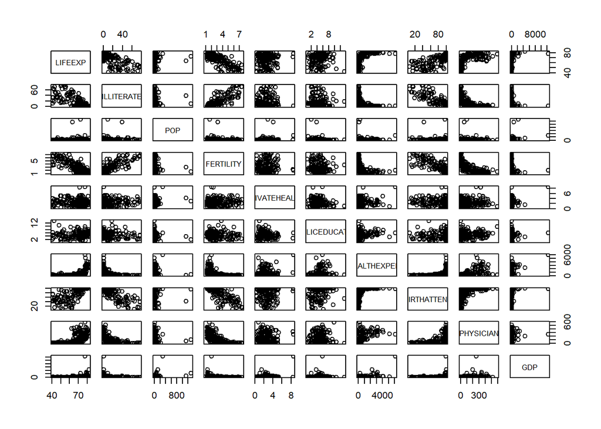

Si nota come i grafici a dispersione delle variabili prese a coppie non mostrino l’esistenza di gruppi separati su cui vale la pena eseguire un’operazione di categorizzazione grazie al clustering.

### Ulteriori studi sul dataset

### PCA

Non avendo informazioni su come siano state selezionate le regioni di partenza proviamo a ricavare 8 cluster basati sulle 8 variabili numeriche selezionate(senza quelle escluse) e confrontare i gruppi con quelli dati. Riselezioniamo le variabili per poter eseguire una PCA sul dataset. Poi eseguiamo la PCA per provare ad eseguire clustering basandoci sulle componenti principali individuate.

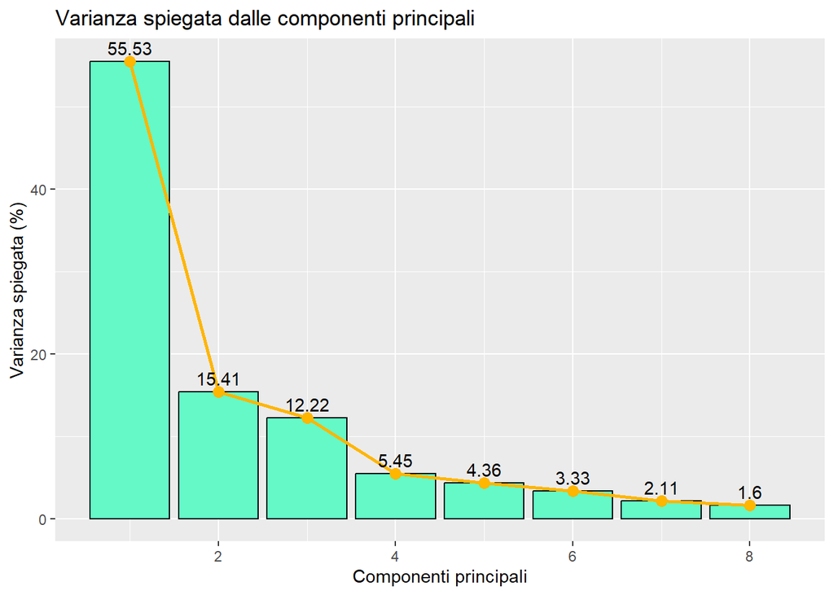

Si nota come risulta difficile ridurre la dimensionalità in quanto le prime 2 componenti principali siano in grado di spiegare solamente il 70% della varianza. Per arrivare ad un valore accettabile (>90%) sarebbe necessario prendere le prime 5 componenti e considerando che si parte da 8 variabili, la riduzione non risulterebbe molto significativa.

```r
pca
```

```
## Standard deviations (1, .., p=8):
## [1] 2.1077075 1.1101527 0.9887782 0.6600603 0.5908420 0.5157935 0.4105515
## [8] 0.3578808
##
## Rotation (n x k) = (8 x 8):
##                         PC1         PC2          PC3         PC4         PC5
## BIRTHATTEND     -0.41857650  0.19280199 -0.039789008 -0.37478950 -0.01917665
## PUBLICEDUCATION -0.09909576 -0.28068350 -0.930934699 -0.06632341 -0.07083912
## ILLITERATE       0.41472095 -0.19510568  0.018065251  0.43360686 -0.22968532
## FERTILITY        0.43251212 -0.17092743  0.004079726  0.09021162  0.12334550
## HEALTHEXPEND    -0.33148590 -0.50868925  0.027401393  0.42975461 -0.01710392
## PHYSICIAN       -0.39515081  0.11815003  0.002520742  0.49124183  0.63975489
## GDP             -0.16075340 -0.73332143  0.335927714 -0.39919400  0.09232454
## LIFEEXP         -0.40502448  0.07922906  0.133528290  0.27132558 -0.71312126
##                        PC6         PC7         PC8
## BIRTHATTEND     -0.2912095  0.67852169 -0.31624099
## PUBLICEDUCATION  0.1645921  0.03508452  0.08377914
## ILLITERATE       0.2843663  0.41334696 -0.54509063
## FERTILITY       -0.3422606  0.51037910  0.61864288
## HEALTHEXPEND    -0.6221856 -0.16908678 -0.17295848
## PHYSICIAN        0.3433012  0.21612114  0.12133084
## GDP              0.3743762  0.10378488  0.06886249
## LIFEEXP          0.2120653  0.14479248  0.40466287
```

Plottiamo le due componenti principali.

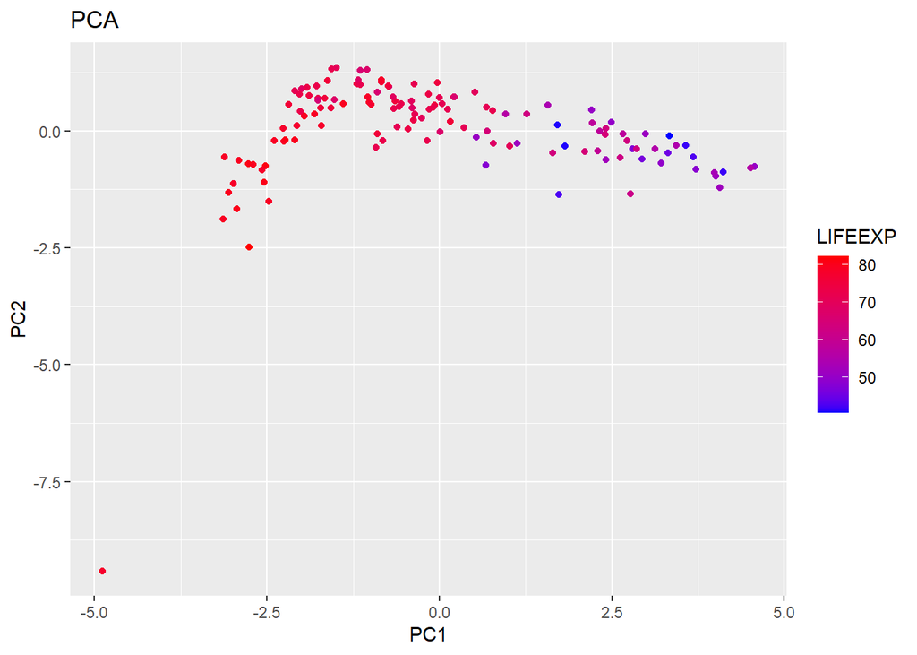

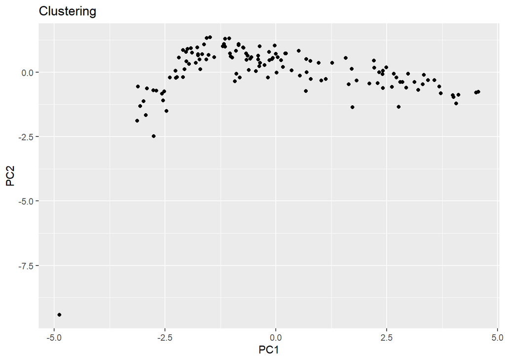

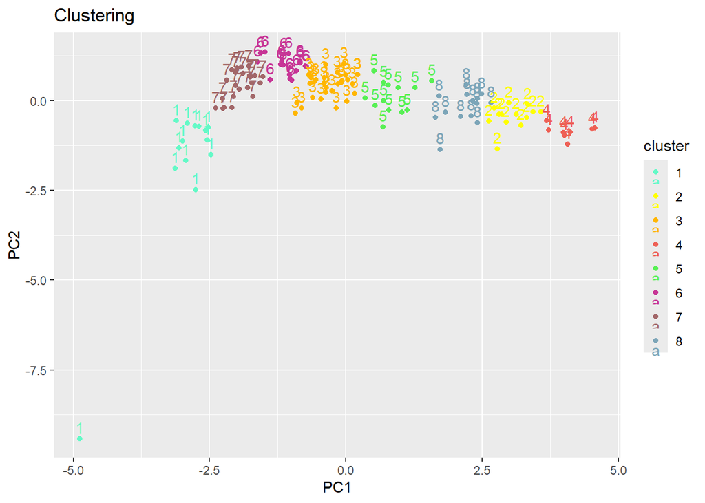

Visualizziamo la mappa con le nuove regioni trovate.

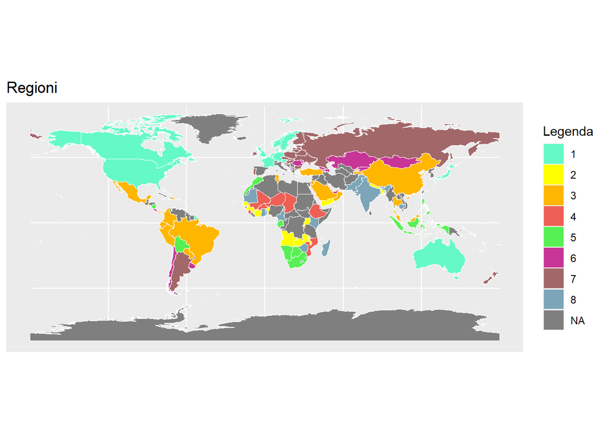

Si nota come i cluster trovati non siano molto significativi in quanto sono presenti moltissimi valori nulli. Nonostante ciò l’attuale gruppo 1 corrisponde abbastanza accuratamente alla regione 8 così come il gruppo 7 alla regione 7. La regione 6 (corrispondente all’Africa) in questo clustering è stata completamente divisa in altri gruppi. Alla regione 4 di partenza si riesce ad associare discretamente bene l’attuale gruppo 8 con l’aggiunta di altri paesi sopratutto appartenenti al continente africano. Riconosciute queste associazioni, concludiamo che i gruppi così trovati non forniscono intuizioni significative per interpretare la formazione dei gruppi presente nel dataset.